# SR_02_RLTD_ORG_CTRL_NA

Direct controlling entity - not applicable · Text report

## Overview

**Description**

Direct Controlling Entity - Literal N/A

**Table**

`SR-P02-T01-ID-RLTD-TAX-EXEMPED-ORGS` (many)

**Location code**

`SCHED-R-PART-02-COL-F`

**Family**

`SCHED-R-PART-02-COL-F` · siblings: SR_02_RLTD_ORG_CTRL_NAME_L1, SR_02_RLTD_ORG_CTRL_NAME_L2

**Data type**

text (xsd: , StringType)

**Scope**

PC

**Status**

unreviewed

3

xpaths mapped (2 observed)

395,215

filings with a value

2009–2024

tax years observed

2

open flags (1 errors)

## Flags

| Severity | Flag | Xpath | Detail |
| --- | --- | --- | --- |
| ⚠ error | `POLARITY` | IRS990ScheduleR/Form990ScheduleRPartII/DirectControllingEntity/NotApplicable | negated element ‘NotApplicable’ pooled with non-negated xpaths |
| ⓘ info | `UNOBSERVED` | IRS990ScheduleR/Form990ScheduleRPartII/DirectControllingEntity/NotApplicable | never observed in TY2009-2024 filings |

## Xpaths

All mapped xpaths (under /Return/ReturnData or /Return/ReturnHeader), oldest first. Charts label each series by its xpath.

| Xpath | Form | Chart label | First year | Last year | Versions | Filings | Repeats in |
| --- | --- | --- | --- | --- | --- | --- | --- |
| IRS990ScheduleR/Form990ScheduleRPartII/DirectControllingEntityNA | Sched R | …cheduleR/Form990ScheduleRPartII/DirectControllingEntityNA | 2009 | 2012 | 17 | 62,510 | 34.9% |
| IRS990ScheduleR/IdRelatedTaxExemptOrgGrp/DirectControllingNACd | Sched R | …0ScheduleR/IdRelatedTaxExemptOrgGrp/DirectControllingNACd | 2013 | 2024 | 37 | 332,705 | 28.4% |
| IRS990ScheduleR/Form990ScheduleRPartII/DirectControllingEntity/NotApplicable | Sched R | …m990ScheduleRPartII/DirectControllingEntity/NotApplicable |  |  |  | 0 |  |

## Coverage

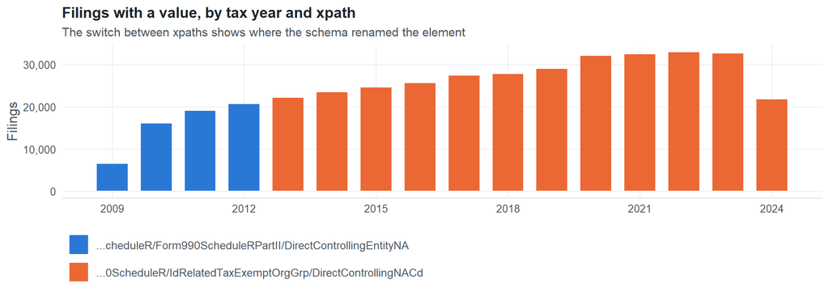

**Table view**

Table view: filings by tax year and series

| Tax year | …cheduleR/Form990ScheduleRPartII/DirectControllingEntityNA | …0ScheduleR/IdRelatedTaxExemptOrgGrp/DirectControllingNACd |
| --- | --- | --- |
| 2009 | 6,551 | 0 |
| 2010 | 16,115 | 0 |
| 2011 | 19,136 | 0 |
| 2012 | 20,708 | 0 |
| 2013 | 0 | 22,251 |
| 2014 | 0 | 23,538 |
| 2015 | 0 | 24,650 |
| 2016 | 0 | 25,651 |
| 2017 | 0 | 27,470 |
| 2018 | 0 | 27,860 |
| 2019 | 0 | 29,092 |
| 2020 | 0 | 32,116 |
| 2021 | 0 | 32,527 |
| 2022 | 0 | 32,964 |
| 2023 | 0 | 32,719 |
| 2024 | 0 | 21,867 |

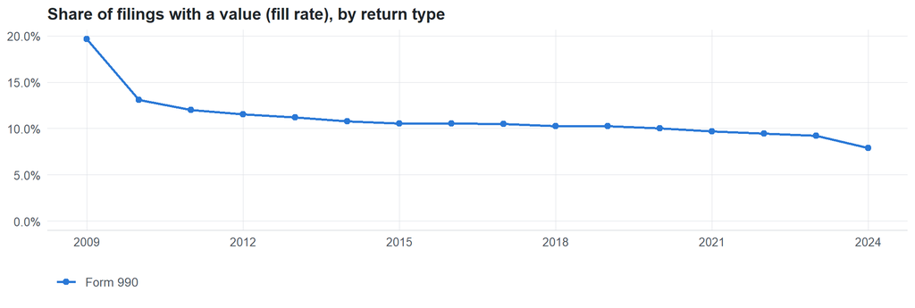

**Table view**

Table view: fill rate

| Tax year | Return type | Filings | All filings | Fill rate |
| --- | --- | --- | --- | --- |
| 2009 | Form 990 | 6,551 | 33,311 | 19.67% |
| 2010 | Form 990 | 16,115 | 123,025 | 13.10% |
| 2011 | Form 990 | 19,136 | 159,504 | 12.00% |
| 2012 | Form 990 | 20,708 | 179,688 | 11.52% |
| 2013 | Form 990 | 22,251 | 198,855 | 11.19% |
| 2014 | Form 990 | 23,538 | 218,619 | 10.77% |
| 2015 | Form 990 | 24,650 | 233,519 | 10.56% |
| 2016 | Form 990 | 25,651 | 243,903 | 10.52% |
| 2017 | Form 990 | 27,470 | 261,612 | 10.50% |
| 2018 | Form 990 | 27,860 | 271,442 | 10.26% |
| 2019 | Form 990 | 29,092 | 283,694 | 10.25% |
| 2020 | Form 990 | 32,116 | 320,342 | 10.03% |
| 2021 | Form 990 | 32,527 | 336,480 | 9.67% |
| 2022 | Form 990 | 32,964 | 349,055 | 9.44% |
| 2023 | Form 990 | 32,719 | 354,768 | 9.22% |
| 2024 | Form 990 | 21,867 | 277,298 | 7.89% |

## Repeating groups

Table cardinality in the concordance: **many**. 2 of 2 observed xpaths repeat within a filing.

Repeating element each xpath was observed in (from the raw indexed xpath)

| Xpath | Repeating element | Filings (summed over years) |
| --- | --- | --- |
| IRS990ScheduleR/Form990ScheduleRPartII/DirectControllingEntityNA | (none) | 28986 |
| IRS990ScheduleR/Form990ScheduleRPartII/DirectControllingEntityNA | IRS990ScheduleR/Form990ScheduleRPartII | 33524 |
| IRS990ScheduleR/IdRelatedTaxExemptOrgGrp/DirectControllingNACd | (none) | 162101 |
| IRS990ScheduleR/IdRelatedTaxExemptOrgGrp/DirectControllingNACd | IRS990ScheduleR/IdRelatedTaxExemptOrgGrp | 170604 |

## Values

| Result | Check | Detail |
| --- | --- | --- |
| ✓ pass | Values are text, not numbers | 0% of values are numeric |
| ✓ pass | No sign of truncation | longest values do not sit at a common field limit |
| ⓘ info | No dominant boilerplate value | most common value covers 100% of filings: “N/A” |

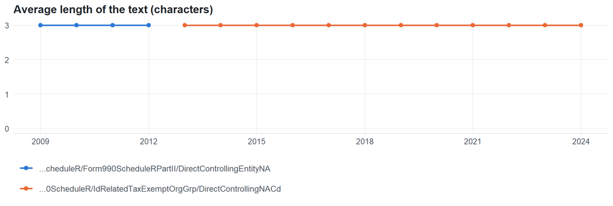

**Table view**

Table view: length and variety by tax year

| Series | Tax year | Filings | Avg length | Max length | Distinct values (approx.) |
| --- | --- | --- | --- | --- | --- |
| …cheduleR/Form990ScheduleRPartII/DirectControllingEntityNA | 2009 | 6,551 | 3 | 3 | 1 |
| …cheduleR/Form990ScheduleRPartII/DirectControllingEntityNA | 2010 | 16,115 | 3 | 3 | 1 |
| …cheduleR/Form990ScheduleRPartII/DirectControllingEntityNA | 2011 | 19,136 | 3 | 3 | 1 |
| …cheduleR/Form990ScheduleRPartII/DirectControllingEntityNA | 2012 | 20,708 | 3 | 3 | 1 |
| …0ScheduleR/IdRelatedTaxExemptOrgGrp/DirectControllingNACd | 2013 | 22,251 | 3 | 3 | 1 |
| …0ScheduleR/IdRelatedTaxExemptOrgGrp/DirectControllingNACd | 2014 | 23,538 | 3 | 3 | 1 |
| …0ScheduleR/IdRelatedTaxExemptOrgGrp/DirectControllingNACd | 2015 | 24,650 | 3 | 3 | 1 |
| …0ScheduleR/IdRelatedTaxExemptOrgGrp/DirectControllingNACd | 2016 | 25,651 | 3 | 3 | 1 |
| …0ScheduleR/IdRelatedTaxExemptOrgGrp/DirectControllingNACd | 2017 | 27,470 | 3 | 3 | 1 |
| …0ScheduleR/IdRelatedTaxExemptOrgGrp/DirectControllingNACd | 2018 | 27,860 | 3 | 3 | 1 |
| …0ScheduleR/IdRelatedTaxExemptOrgGrp/DirectControllingNACd | 2019 | 29,092 | 3 | 3 | 1 |
| …0ScheduleR/IdRelatedTaxExemptOrgGrp/DirectControllingNACd | 2020 | 32,116 | 3 | 3 | 1 |
| …0ScheduleR/IdRelatedTaxExemptOrgGrp/DirectControllingNACd | 2021 | 32,527 | 3 | 3 | 1 |
| …0ScheduleR/IdRelatedTaxExemptOrgGrp/DirectControllingNACd | 2022 | 32,964 | 3 | 3 | 1 |
| …0ScheduleR/IdRelatedTaxExemptOrgGrp/DirectControllingNACd | 2023 | 32,719 | 3 | 3 | 1 |
| …0ScheduleR/IdRelatedTaxExemptOrgGrp/DirectControllingNACd | 2024 | 21,867 | 3 | 3 | 1 |

Most common values by xpath (all years; long values truncated)

| Series | Value | Filings | Share |
| --- | --- | --- | --- |
| …cheduleR/Form990ScheduleRPartII/DirectControllingEntityNA | N/A | 62,510 | 100.0% |
| …0ScheduleR/IdRelatedTaxExemptOrgGrp/DirectControllingNACd | N/A | 332,705 | 100.0% |

## Examples

| Tax year | Return | Xpath | Organization | Value | Source |
| --- | --- | --- | --- | --- | --- |
| 2024 | 990 | IRS990ScheduleR/IdRelatedTaxExemptOrgGrp/DirectControllingNACd | THE CLEVELAND CLINIC FOUNDATION | N/A | [XML](https://gt990datalake-rawdata.s3.amazonaws.com/EfileData/XmlFiles/202513189349302136_public.xml) |
| 2023 | 990 | IRS990ScheduleR/IdRelatedTaxExemptOrgGrp/DirectControllingNACd | Neurology Associates of Stony Brook University Faculty Practice Corp | N/A | [XML](https://gt990datalake-rawdata.s3.amazonaws.com/EfileData/XmlFiles/202531339349306648_public.xml) |
| 2022 | 990 | IRS990ScheduleR/IdRelatedTaxExemptOrgGrp/DirectControllingNACd | RIVER GARDEN GERIATRIC | N/A | [XML](https://gt990datalake-rawdata.s3.amazonaws.com/EfileData/XmlFiles/202313079349302866_public.xml) |
| 2021 | 990 | IRS990ScheduleR/IdRelatedTaxExemptOrgGrp/DirectControllingNACd | VIRGINIA BEACH PUBLIC SCHOOLS | N/A | [XML](https://gt990datalake-rawdata.s3.amazonaws.com/EfileData/XmlFiles/202310839349300011_public.xml) |
| 2020 | 990 | IRS990ScheduleR/IdRelatedTaxExemptOrgGrp/DirectControllingNACd | PLUMBERS & STEAMFITTERS LOC 60 ED TRUST | N/A | [XML](https://gt990datalake-rawdata.s3.amazonaws.com/EfileData/XmlFiles/202201749349301215_public.xml) |
| 2019 | 990 | IRS990ScheduleR/IdRelatedTaxExemptOrgGrp/DirectControllingNACd | BAPTIST BESTHEALTH INC | N/A | [XML](https://gt990datalake-rawdata.s3.amazonaws.com/EfileData/XmlFiles/202112259349301966_public.xml) |
| 2018 | 990 | IRS990ScheduleR/IdRelatedTaxExemptOrgGrp/DirectControllingNACd | SEMCOA INC DBA SOUTHEAST MA | N/A | [XML](https://gt990datalake-rawdata.s3.amazonaws.com/EfileData/XmlFiles/202000919349300125_public.xml) |
| 2017 | 990 | IRS990ScheduleR/IdRelatedTaxExemptOrgGrp/DirectControllingNACd | TELEOS PREPARATORY ACADEMY | N/A | [XML](https://gt990datalake-rawdata.s3.amazonaws.com/EfileData/XmlFiles/201901339349307160_public.xml) |
| 2016 | 990 | IRS990ScheduleR/IdRelatedTaxExemptOrgGrp/DirectControllingNACd | CAMPAIGN TO END OBESITY | N/A | [XML](https://gt990datalake-rawdata.s3.amazonaws.com/EfileData/XmlFiles/201733189349306208_public.xml) |
| 2015 | 990 | IRS990ScheduleR/IdRelatedTaxExemptOrgGrp/DirectControllingNACd | FEDERATION CCRC OPERATIONS CORP | N/A | [XML](https://gt990datalake-rawdata.s3.amazonaws.com/EfileData/XmlFiles/201731289349302158_public.xml) |
| 2014 | 990 | IRS990ScheduleR/IdRelatedTaxExemptOrgGrp/DirectControllingNACd | ARAPAHOE HOUSE INC | N/A | [XML](https://gt990datalake-rawdata.s3.amazonaws.com/EfileData/XmlFiles/201611179349300921_public.xml) |
| 2013 | 990 | IRS990ScheduleR/IdRelatedTaxExemptOrgGrp/DirectControllingNACd | ST LOUIS VOLUNTEERS OF AMERICA | N/A | [XML](https://gt990datalake-rawdata.s3.amazonaws.com/EfileData/XmlFiles/201413539349301006_public.xml) |

## Reviewer checklist

- The definition matches the form line and instructions for every xpath’s schema years.
- Every xpath pooled here measures the same thing on the 990 and 990-EZ (close enough for analysis).
- The coverage chart has no unexplained gaps or jumps between tax years.
- Each open flag is fixed, or accepted with a note in validation_log.csv.
- Values answer the question on the form line (not another line’s explanation).
- Boilerplate such as ‘See Schedule O’ or ‘N/A’ is expected here, or should be treated as missing.
- Text that is really a number or a code is flagged for a different data type.

Record the review as a row in `inst/extdata/src/validation_log.csv` (variable_name, reviewer, date, status, note). Evidence built 2026-09-23 17:09:04 MST from the ef2 DuckDB builds (tax years 2009–2024).